# Lec 04: Categorical Data Analysis

Last Updated 2017-10-15 20:41:07

#### Spam Data

This set of lecture notes uses data on incoming emails for the first three months of 2012 for David Diez’s (An Open Intro Statistics Textbook author) Gmail Account, early months of 2012. All personally identifiable information has been removed.

```r
email <- read.delim("https://norcalbiostat.netlify.com/data/email.txt", header=TRUE, sep="\t")
email <- email %>% mutate(hasnum = ifelse(number %in% c("big", "small"), 1, 0))
```

Two categorical variables of current interest are

- `spam` (0/1 binary indicator if a an email is flagged as spam). Converted into a Ham/Spam factor variable.
- `number` categorical variable describing the size of the numbers contained in the email.
  - `none`: No numbers
  - `small`: Only values under 1 million
  - `big`: A value of 1 million or more
- `hasnum`: 0/1 binary indicator for if the email contains any sized number

#### Chi-Squared Distribution

Much of categorical data analysis uses the $\chi^{2}$ distribution.

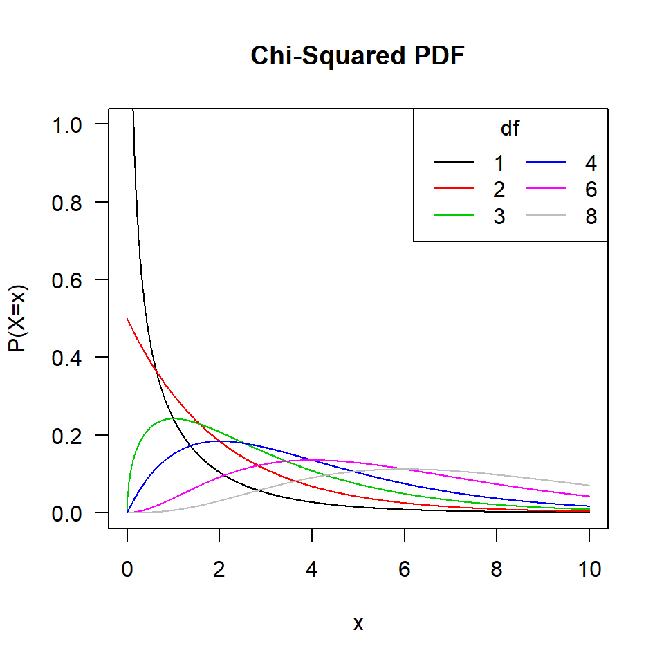

- The shape is controlled by a degrees of freedom parameter (df)
- Is used in many statistical tests for categorical data.
- Is always positive (it’s squared!)
  - High numbers result in low p-values
- Mathematically connected to many other distributions
  - Special case of the gamma distribution (One of the most commonly used statistical distributions)
  - The sample variance has a $\chi^{2}_{n-1}$ distribution.
  - The sum of $k$ independent standard normal distributions has a $\chi^{2}_{k}$ distribution.
  - The ANOVA F-statistic is the ratio of two $\chi^{2}$ distributions divided by their respective degrees of freedom.

# Difference of two proportions

Now let’s consider comparisons of proportions in two independent samples.

**Ex**: Comparison of proportions of head injuries sustained in auto accidents by passengers wearing seat belts to those not wearing seat belts. You may have already guessed the form of the estimate: $\hat{p}_1 - \hat{p}_2$.

We are not going to go in depth into the calculations for the test statistic for a test of the difference in proportions. The OpenIntro textbook explains the assumptions and equations very well. Instead we are going to see how to use R to perform these calculations for us.

Since the sample proportion can be calculated as the mean of a binary indicator variable, we can use the same `t.test` function in R to conduct a hypothesis test and create a confidence interval.

### Example 1: Do numbers in emails affect rate of spam? (Case level data)

If we look at the rate of spam for emails with and without numbers, we see that 6% of emails with numbers are flagged as spam compared to 27% of emails without numbers are flagged as spam.

```r
email %>% group_by(hasnum) %>% summarize(p.spam=round(mean(spam),2))
```

```
## # A tibble: 2 × 2
##   hasnum p.spam
##    <dbl>  <dbl>
## 1      0   0.27
## 2      1   0.06
```

This is such a large difference that we don’t really *need* a statistical test to tell us that this difference is significant. But we will do so anyhow for examples sake.

1. **State the research question:** Are emails that contain numbers more likely to be spam?
2. **Define your parameters:**  
   Let $p_{nonum}$ be the proportion of emails *without* numbers that are flagged as spam.  
   Let $p_{hasnum}$ be the proportion of emails *with* numbers that are flagged as spam.
3. **Set up your statistical hypothesis:**  
   $H_{0}: p_{nonum} = p_{hasnum}$  
   $H_{A}: p_{nonum} \neq p_{hasnum}$
4. **Check assumptions:** Use the pooled proportion $\hat{p}$ to check the success-failure condition.

```r
p.hat <- mean(email$spam)
p.hat
```

```
## [1] 0.09359857
```

- $\hat{p}*n_{nonum}$ = `p.hat * sum(email$hasnum==0)` = 51.3856159
- $\hat{p}*n_{hasnum}$ = `p.hat * sum(email$hasnum==1)` = 315.6143841
- $(1-\hat{p})*n_{nonum}$ = `(1-p.hat)* sum(email$hasnum==0)` = 497.6143841
- $(1-\hat{p})*n_{hasnum}$ = `(1-p.hat)* sum(email$hasnum==1)` = 3056.3856159

The success-failure condition is satisfied since all values are at least 10, and we can safely apply the normal model.

5. **Test the hypothesis** by calculating a test statistic and corresponding p-value. Interpret the results in context of the problem.

```r
t.test(spam~hasnum, data=email)
```

```
##
##  Welch Two Sample t-test
##
## data:  spam by hasnum
## t = 10.623, df = 603.6, p-value < 2.2e-16
## alternative hypothesis: true difference in means is not equal to 0
## 95 percent confidence interval:
##  0.1685303 0.2449747
## sample estimates:
## mean in group 0 mean in group 1
##      0.27140255      0.06465006
```

### Example 2: Are mammograms helpful? (Summary numbers only)

Test whether there was a difference in breast cancer deaths in the mammogram and control groups. By entering in $x$ and $n$ as vectors we can test equivalence of these two proportions. The assumptions for using the normal model for this test have been discussed in detail in the textbook.

```r
prop.test(x=c(500, 505), n=c(44925, 44910))
```

```
##
##  2-sample test for equality of proportions with continuity
##  correction
##
## data:  c(500, 505) out of c(44925, 44910)
## X-squared = 0.01748, df = 1, p-value = 0.8948
## alternative hypothesis: two.sided
## 95 percent confidence interval:
##  -0.001512853  0.001282751
## sample estimates:
##     prop 1     prop 2
## 0.01112966 0.01124471
```

# Contingency tables

- Both the explanatory and the response variables are categorical (Nominal or Ordinal)
- Tables representing all combinations of levels of explanatory and response variables
- A.k.a Two-way tables or *cross-tabs*
- Numbers in table represent Counts of the number of cases in each cell

```r
tab <- table(email$spam, email$number)
tab
```

```
##
##      big none small
##   0  495  400  2659
##   1   50  149   168
```

# Tests of Association

There are three main tests of association for $rxc$ contingency table.

- Test of Goodness of Fit
- Tests of Independence
- Test of Homogeneity

**Notation**

- $r$ is the number of rows and indexed by $i$
- $c$ is the number of columns and indexed by $j$.

## Goodness of Fit

- OpenIntro Statistics: Chapter 6.3
- Tests whether a set of multinomial counts is distributed according to a theoretical set of population proportions.
- Does a set of categorical data come from a claimed distribution?
- Are the observed frequencies consistent with theory?

$H_{0}$: The data come from the claimed discrete distribution  
$H_{A}$: The data to not come from the claimed discrete distribution.

## Test of Independence

- OpenIntro Statistics: Chapter 6.4
- Determine whether two categorical variables are associated with one another in the population
  - Ex. Race and smoking, or education level and political affiliation.
- Data are collected at random from a population and the two categorical variables are observed on each unit.

$H_{0}: p_{ij} = p_{i.}p_{.j}$  
$H_{A}: p_{ij} \neq p_{i.}p_{.j}$

## Test of Homogeneity

- A test of homogeneity tests whether two (or more) sets of multinomial counts come from different sets of population proportions.
- Does two or more sub-groups of a population share the same distribution of a single categorical variable?
  - Ex: Do people of different races have the same proportion of smokers?
  - Ex: Do different education levels have different proportions of Democrats, Republicans, and Independents?
- Data on one characteristic is collected from randomly sampling individuals within each subroup of the second characteristic.

$H_{0}:$

$$p_{11} = p_{12} = \ldots = p_{1c}$$
$$p_{21} = p_{22} = \ldots = p_{2c}$$
$$\qquad \vdots$$
$$p_{r1} = p_{r2} = \ldots = p_{rc}$$

$H_{A}:$ At least one of the above statements is false.

All three tests use the **Pearsons’ Chi-Square** test statistic.

## Pearsons’ Chi-Square

The chi-squared test statistic is the sum of the squared differences between the observed and expected values, divided by the expected value.

### One way table

$$\chi^{2} = \sum^{r}_{i=1} \frac{(O_{i}-E_{i})^2}{E_{i}}$$

- $O_{i}$ observed number of type $i$
- $E_{i}$ expected number of type $i$. Equal to $Np_{i}$ under the null hypothesis
- N is the total sample size
- df = r-1

### Two way tables

$$\chi^{2} = \sum^{r}_{i=1}\sum^{c}_{j=1} \frac{(O_{ij}-E_{ij})^2}{E_{ij}}$$

- $O_{ij}$ observed number in cell $ij$
- $E_{ij} = Np_{i.}p_{.j}$ under the null hypothesis
- N is the total sample size
- df = (r-1)(c-1)

### Conducting these tests in R.

- Test of equal or given proportions using `prop.test()`

```r
prop.test(table(email$number, email$spam))
```

```
##
##  3-sample test for equality of proportions without continuity
##  correction
##
## data:  table(email$number, email$spam)
## X-squared = 243.51, df = 2, p-value < 2.2e-16
## alternative hypothesis: two.sided
## sample estimates:
##    prop 1    prop 2    prop 3
## 0.9082569 0.7285974 0.9405730
```

- Chi-squared contingency table tests and goodness-of-fit tests using `chisq.test()`.  
  This function can take raw data as input

```r
chisq.test(email$number, email$spam)
```

```
##
##  Pearson's Chi-squared test
##
## data:  email$number and email$spam
## X-squared = 243.51, df = 2, p-value < 2.2e-16
```

or a table object.

```r
chisq.test(tab)
```

```
##
##  Pearson's Chi-squared test
##
## data:  tab
## X-squared = 243.51, df = 2, p-value < 2.2e-16
```

### prop.test vs chisq.test()

```r
pt.out <- prop.test(table(email$number, email$spam))
cs.out <- chisq.test(tab)
```

- Same calculated test statistic and p-value

```r
c(pt.out$statistic, pt.out$p.value)
```

```
##    X-squared
## 2.435137e+02 1.323321e-53
```

```r
c(cs.out$statistic, cs.out$p.value)
```

```
##    X-squared
## 2.435137e+02 1.323321e-53
```

- `prop.test`
  - has a similar output appearance to other hypothesis tests
  - shows sample proportions of outcome within each group
- `chisq.test`
  - stores the matricies of $O_{ij}$, $E_{ij}$, the residuals and standardized residuals

```r
cs.out$expected
```

```
##
##           big      none     small
##   0 493.98878 497.61438 2562.3968
##   1  51.01122  51.38562  264.6032
```

### Mosaicplots

- The Pearson $\chi^{2}$ test statistic = Sum of squared residuals.
- A shaded mosaicplot shows the magnitude of the residuals.
  - Blue (positive residuals) = More frequent than expected
  - Red (negative residuals) = Less frequent than expected.

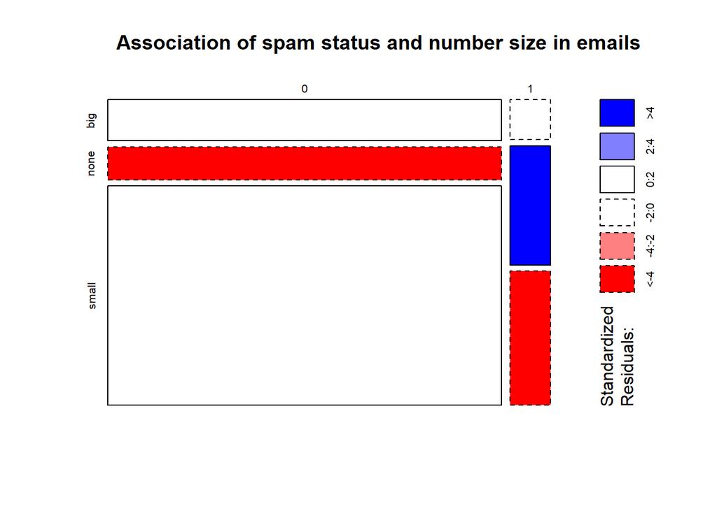

```r
mosaicplot(tab, shade=TRUE, main="Association of spam status and number size in emails")
```

There are more spam emails with no numbers, fewer Ham emails with no numbers, and fewer spam emails with small numbers than would be expected if these factors were independent.

- More information on mosaicplots - http://www.datavis.ca/online/mosaics/about.html

# Assumptions and Extensions

- Simple random sample
- Adequate expected cell counts
  - At least 5 in all cells of a 2x2, or at least 80% of cells in a larger table.
  - NO cells with 0 cell count
- Observations are independent

If one or more of these assumptions are not satisfied, other methods may still be useful.

- McNemar’s Test for paired or correlated data
- Fishers exact test for when cell sizes are small (<5-10)
- Inter-rater reliability: Concordant and Discordant Pairs